# The runner package

Dawid Kałędkowski

2019-12-09

## About

Package contains running functions (rolling or sliding window) with additional options. `runner` provides extended functionality like varying windows size, windows dependent on date, handling missing value. `runner` brings also other utility functions like filling missing values, rolling streak and rolling which.

## Installation

Install package from from GitHub or from CRAN.

```r
# devtools::install_github("gogonzo/runner")
install.packages("runner")
```

## Running windows

`runner` functionality revolves around time series and running windows. Diagram below illustrates what running windows are - in this case running `k = 4` windows. For each of 15 elements of a vector each window contains current 4 elements.

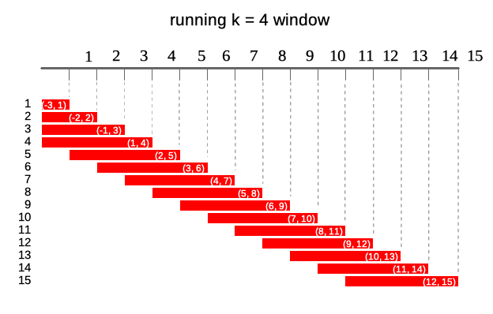

Windows are defined by several parameters, like size, lag and indexes of observation (or date).

### Window size

`k` denotes number of elements in window. If `k` is a single value then window size is constant for all elements of x. For varying window size one should specify `k` as integer vector of `length(k) == length(x)` where each element of `k` defines window length. If `k` is empty it means that window will be cumulative (like `base::cumsum`). Example below illustrates window of `k = 4` for 10’th element of vector `x`.

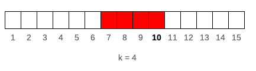

### Window lag

`lag` denotes how many observations windows will be lagged by. If `lag` is a single value than it’s constant for all elements of x. For varying lag size one should specify `lag` as integer vector of `length(lag) == length(x)` where each element of `lag` defines lag of window. Default value of `lag = 0`. Example below illustrates window of `k = 4` lagged by `lag = 2` for 10’th element of vector `x`. Lag can also be negative value, which shifts window forward instead of backward.

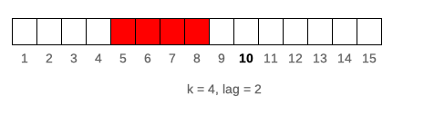

### Windows depending on date

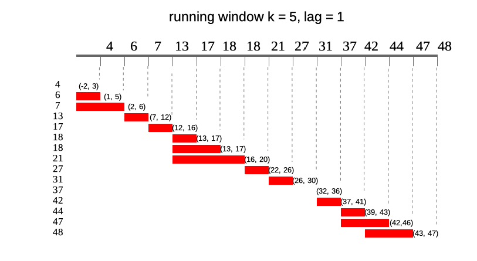

### `NA` padding

Using `runner` one can also specify `na_pad = TRUE` which would return `NA` for any window which is partially out of range - meaning that there is no sufficient number of observations to fill the window. By default `na_pad = FALSE`, which means that incomplete windows are calculated anyway. `na_pad` is applied on normal cumulative windows and on windows depending on date.

## Using package

### Any R function with `runner`

Package contains most fundamental function `runner::runner` which gives possibility to apply any R function `f` on running window. `runner::runner` serve as `sapply` on running windows. Only `x` value needs to be specified while `k`, `lag` and `idx` are optional.

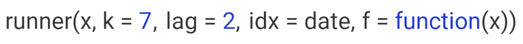

Below example of using `base::mean` inside of the `runner` function.

```r
library(runner)
x <- runif(15)
k <- sample(1:15, 15, replace = TRUE)
idx <- cumsum(sample(c(1, 2, 3, 4), 15, replace = TRUE))

# simple call
simple_mean <- runner(x = x, k = 4, f = mean)

# additional arguments for mean
trimmed_mean <- runner(x = x, k = 4, f = function(x) mean(x, trim = 0.05))

# varying window size
varying_window <- runner(x = x, k = k, f = function(x) mean(x, trim = 0.05))

# windows depending on date
date_windows <- runner(x = x, k = k, idx = idx, f = function(x) mean(x, trim = 0.05))

data.frame(x, k, idx, simple_mean, trimmed_mean, varying_window, date_windows)
```

```
##            x  k idx simple_mean trimmed_mean varying_window date_windows
## 1  0.5187593 11   2   0.5187593    0.5187593      0.5187593    0.5187593
## 2  0.8779030 14   3   0.6983311    0.6983311      0.6983311    0.6983311
## 3  0.8291403 12   4   0.7419342    0.7419342      0.7419342    0.7419342
## 4  0.5064969  9   8   0.6830748    0.6830748      0.6830748    0.6830748
## 5  0.4876408  3   9   0.6752952    0.6752952      0.6077593    0.4970688
## 6  0.4841933 12  12   0.5768678    0.5768678      0.6173556    0.6173556
## 7  0.6139901 14  15   0.5230803    0.5230803      0.6168748    0.6168748
## 8  0.1275693  6  19   0.4283484    0.4283484      0.5081718    0.3707797
## 9  0.7638903  4  22   0.4974108    0.4974108      0.4974108    0.4457298
## 10 0.3246819  4  25   0.4575329    0.4575329      0.4575329    0.5442861
## 11 0.9386148 14  27   0.5386891    0.5386891      0.5884436    0.5537493
## 12 0.8685000 13  30   0.7239218    0.7239218      0.6117817    0.6046513
## 13 0.1299957  8  33   0.5654481    0.5654481      0.5314294    0.6457035
## 14 0.9807301 15  37   0.7294602    0.7294602      0.6037218    0.6485045
## 15 0.9519282  7  40   0.7327885    0.7327885      0.7083344    0.9663292
```

### builtin functions

With `runner` one can use any R functions, but some of them are optimized for speed reasons. These functions are:  
- aggregating functions - `length_run`, `min_run`, `max_run`, `minmax_run`, `sum_run`, `mean_run`, `streak_run`  
- utility functions - `fill_run`, `lag_run`, `which_run`

More details about using built-in functions.